# Performative Prediction: V4→V5 Model Shock 的 Selection vs Causal 识别（v4）

这一版 notebook 的目的，是把分析进一步收紧到当前真正的核心问题上：

> 在 model / policy shock 之后，哪些用户被更系统性地推入了 `inc`，这些人本来是否更危险（selection by model change），以及 treatment path 是否还带来了额外的 hazard（causal component）。

本版相对于 v3 的主要调整有三点：

1. survival / hazard 继续作为主因果证据；
2. matched comparison 明确保留为辅助证据；
3. selection 的摘要进一步收紧为“弱、方向性证据”，并把分解明确写成 bookkeeping，而不是正式份额识别。

## 证据层次

- **主因果证据**：Part 3–4，离散时间 hazard + IPTW 一致性检查
- **Selection 识别链**：Part 5–8，谁被推向 `inc` → 是否更危险 → 可能通过哪些 `X`
- **辅助因果证据**：Part 9，matched comparison
- **背景层**：Part 10，prediction layer，非主问题

## 识别假设（maintained）

我们保留以下研究设计前提，不在本 notebook 中继续争论其合理性：

$$ Y(a) \perp A_t \mid X_t $$

即系统在每个时点的处理分配，给定可观测事件级 `X_t` 后可视为条件可交换。

```python
import warnings; warnings.filterwarnings("ignore")
import numpy as np, pandas as pd, matplotlib.pyplot as plt, seaborn as sns
from scipy import stats
from sklearn.model_selection import StratifiedKFold, GroupKFold
from sklearn.metrics import roc_auc_score, brier_score_loss, log_loss, roc_curve
import statsmodels.api as sm
import statsmodels.formula.api as smf
import xgboost as xgb
import os
os.environ["CUDA_VISIBLE_DEVICES"] = "1"

plt.rcParams.update({
    "font.family": "DejaVu Sans",
    "font.size": 10,
    "figure.dpi": 180,
    "savefig.dpi": 180,
    "axes.titlesize": 12,
    "axes.labelsize": 10,
    "figure.figsize": (9, 5),
    "legend.fontsize": 8,
})
sns.set_style("whitegrid")

CFG = dict(
    path_2w="working_data/2wcase_updated.csv",
    model_path_v4="working_data/model/v4-短期.model",
    feature_path_v4="working_data/model/v4-短期.xlsx",
    model_path_v5="working_data/model/v5-短期.model",
    feature_path_v5="working_data/model/v5-短期.xlsx",
    n_folds=5,
    seed=42,
    xgb_device="cuda",
    max_followup_days=60,
)

def stars(p):
    if p < 0.01: return "***"
    if p < 0.05: return "**"
    if p < 0.10: return "*"
    return ""

def stata_table(model, title=""):
    print(f"\n{'─'*75}")
    if title:
        print(f"  {title}")
    print(f"{'─'*75}")
    print(f"  {'':.<24s} {'Coef.':>9s} {'Std.Err.':>10s} {'z':>8s} {'P>|z|':>8s}  {'[95% CI]':>20s}")
    print(f"{'─'*75}")
    ci = model.conf_int()
    for v in model.params.index:
        c = model.params[v]
        se = model.bse[v]
        z = c / se if se > 0 else 0
        p = model.pvalues[v]
        lo, hi = ci.loc[v, 0], ci.loc[v, 1]
        print(f"  {v:.<24s} {c:>9.4f} {se:>10.4f} {z:>8.2f} {p:>8.4f}  [{lo:>8.4f}, {hi:>8.4f}] {stars(p)}")
    print(f"{'─'*75}")
    print(f"  N = {int(model.nobs):,}   AIC = {model.aic:.1f}")
    print("  * p<0.10, ** p<0.05, *** p<0.01")

def compute_smd(t, c):
    t = pd.Series(t).dropna()
    c = pd.Series(c).dropna()
    if len(t) < 2 or len(c) < 2:
        return np.nan
    ps = np.sqrt((t.var() + c.var()) / 2)
    return (t.mean() - c.mean()) / ps if ps > 0 else 0

def kaplan_meier(T, E):
    dk = pd.DataFrame({"T": T, "E": E}).dropna()
    ts = sorted(dk["T"].unique())
    nr = len(dk)
    s = 1.0
    out = [{"time": 0, "survival": 1.0}]
    for t in ts:
        d = ((dk["T"] == t) & (dk["E"] == 1)).sum()
        c_ = ((dk["T"] == t) & (dk["E"] == 0)).sum()
        if nr > 0:
            s *= (1 - d / nr)
        out.append({"time": t, "survival": s})
        nr -= (d + c_)
    return pd.DataFrame(out)

def safe_qcut_rank(s, q, labels=False):
    r = pd.Series(s).rank(method="first")
    q_eff = min(q, r.nunique())
    if q_eff < 2:
        return pd.Series(np.zeros(len(r), dtype=int), index=r.index)
    return pd.qcut(r, q=q_eff, labels=labels, duplicates="drop")

def rd_ci(y1, y0, alpha=0.05):
    y1 = pd.Series(y1).dropna().astype(float)
    y0 = pd.Series(y0).dropna().astype(float)
    p1, p0 = y1.mean(), y0.mean()
    n1, n0 = len(y1), len(y0)
    rd = p1 - p0
    se = np.sqrt((p1 * (1 - p1) / max(n1, 1)) + (p0 * (1 - p0) / max(n0, 1)))
    z = stats.norm.ppf(1 - alpha / 2)
    return rd, rd - z * se, rd + z * se

def xgb_crossfit(df, feat_list, target, cfg, group_col=None, max_depth=4, colsample=0.6, mcw=30):
    fl = [f for f in feat_list if f in df.columns]
    if len(fl) == 0:
        return np.full(len(df), np.nan), 0.5, 0.0, 0

    X = df[fl].values.astype(np.float32)
    y = df[target].values.astype(int)
    oof = np.full(len(df), np.nan)

    use_group = (
        group_col is not None
        and group_col in df.columns
        and df[group_col].nunique() >= cfg["n_folds"]
    )

    if use_group:
        splitter = GroupKFold(n_splits=cfg["n_folds"])
        split_iter = splitter.split(X, y, groups=df[group_col].values)
    else:
        splitter = StratifiedKFold(n_splits=cfg["n_folds"], shuffle=True, random_state=cfg["seed"])
        split_iter = splitter.split(X, y)

    aucs = []
    params = {
        "objective": "binary:logistic",
        "eval_metric": "logloss",
        "max_depth": max_depth,
        "learning_rate": 0.05,
        "subsample": 0.8,
        "colsample_bytree": colsample,
        "min_child_weight": mcw,
        "reg_alpha": 0.1,
        "reg_lambda": 1.0,
        "device": cfg["xgb_device"],
        "verbosity": 0,
    }

    for tr_i, va_i in split_iter:
        dt = xgb.DMatrix(X[tr_i], label=y[tr_i], feature_names=fl, missing=np.nan)
        dv = xgb.DMatrix(X[va_i], label=y[va_i], feature_names=fl, missing=np.nan)
        bst = xgb.train(
            params,
            dt,
            num_boost_round=300,
            evals=[(dv, "v")],
            early_stopping_rounds=30,
            verbose_eval=False,
        )
        oof[va_i] = bst.predict(dv)
        if len(np.unique(y[va_i])) == 2:
            aucs.append(roc_auc_score(y[va_i], oof[va_i]))

    return oof, (np.mean(aucs) if aucs else 0.5), (np.std(aucs) if aucs else 0.0), len(fl)

print("Utilities loaded.")
```

```
Utilities loaded.
```

## Part 1. 数据加载、模型打分、overlap window 与 user-level survival 数据构造

```python
# ── Data, scoring, overlap, survival setup, merge HD X ──
def basic_clean(df):
    df = df.copy()
    df["first_done_date"] = pd.to_datetime(df["first_done_date"], errors="coerce")
    for c in ["first_bf_credit", "first_af_credit"]:
        df[c] = pd.to_numeric(df[c], errors="coerce")
    for c in ["mob1_label7", "mob2_label7"]:
        df[c] = pd.to_numeric(df[c], errors="coerce") if c in df.columns else np.nan
    if "repay_cycle_end_date" in df.columns:
        df["repay_cycle_end_date"] = pd.to_datetime(df["repay_cycle_end_date"], errors="coerce")

    df = df.dropna(subset=["first_done_date", "first_bf_credit", "first_af_credit"]).copy()
    df["event_date"] = df["first_done_date"].dt.normalize()

    df["treat_dir"] = np.select(
        [
            df["first_af_credit"] > df["first_bf_credit"],
            df["first_af_credit"] == df["first_bf_credit"],
            df["first_af_credit"] < df["first_bf_credit"],
        ],
        ["inc", "same", "dec"],
        default="unknown",
    )
    df = df[df["treat_dir"].isin(["inc", "same", "dec"])].copy()
    df["is_inc"] = (df["treat_dir"] == "inc").astype(int)
    df["is_dec"] = (df["treat_dir"] == "dec").astype(int)
    df["delta_abs"] = df["first_af_credit"] - df["first_bf_credit"]

    if "model_type" in df.columns:
        mt = df["model_type"].astype(str).str.upper()
        df["model_family"] = np.where(mt.str.contains("V4"), "v4", np.where(mt.str.contains("V5"), "v5", "other"))
    else:
        df["model_family"] = "unknown"

    # 这里默认: NaN 已在前序处理阶段代表“不成熟 / 不可用”, 本 notebook 仅使用已成熟样本.
    for c in ["mob1_label7", "mob2_label7"]:
        df[f"{c}_mature"] = df[c].notna().astype(int)
    df["label_any_mature"] = (df["mob1_label7_mature"] | df["mob2_label7_mature"]).astype(int)
    df["default"] = np.where(
        df["label_any_mature"] == 1,
        np.fmax(df["mob1_label7"].fillna(0), df["mob2_label7"].fillna(0)),
        np.nan,
    )
    return df

df_2w = basic_clean(pd.read_csv(CFG["path_2w"], low_memory=False))

feat_df_v4 = pd.read_excel(CFG["feature_path_v4"])
feat_df_v5 = pd.read_excel(CFG["feature_path_v5"])

def gl(f):
    return f["索引"].dropna().tolist() if "索引" in f.columns else f.iloc[:, 0].dropna().tolist()

CFG["feat_v4"] = gl(feat_df_v4)
CFG["feat_v5"] = gl(feat_df_v5)
CFG["feat_inter"] = sorted(set(CFG["feat_v4"]) & set(CFG["feat_v5"]))
CFG["feat_union"] = sorted(set(CFG["feat_v4"]) | set(CFG["feat_v5"]))

bv4 = xgb.Booster(); bv4.load_model(CFG["model_path_v4"])
bv5 = xgb.Booster(); bv5.load_model(CFG["model_path_v5"])

def score_with_model(df, booster, flist, out_col):
    X = pd.DataFrame(
        {f: pd.to_numeric(df[f], errors="coerce").values if f in df.columns else np.nan for f in flist},
        index=df.index,
    )
    df[out_col] = booster.predict(xgb.DMatrix(X.values, feature_names=flist, missing=np.nan))
    return df

df_2w = score_with_model(df_2w, bv4, CFG["feat_v4"], "score_v4")
df_2w = score_with_model(df_2w, bv5, CFG["feat_v5"], "score_v5")

dm = df_2w.groupby(["event_date", "model_family"]).size().unstack(fill_value=0)
ov = dm.index[(dm.get("v4", pd.Series(dtype=int)) > 0) & (dm.get("v5", pd.Series(dtype=int)) > 0)]
CFG["overlap_start"] = ov.min()
CFG["overlap_end"] = ov.max()

df_sorted = df_2w.sort_values(["user_id", "event_date", "first_done_date"])
users_pre = set(df_sorted[df_sorted["event_date"] < CFG["overlap_start"]]["user_id"])
users_in = set(df_sorted[(df_sorted["event_date"] >= CFG["overlap_start"]) & (df_sorted["event_date"] <= CFG["overlap_end"])]["user_id"])
continuing = users_pre & users_in

df_aw = df_sorted[
    (df_sorted["event_date"] >= CFG["overlap_start"])
    & (df_sorted["event_date"] <= CFG["overlap_end"])
    & (df_sorted["user_id"].isin(continuing))
].copy()

anchor = df_aw.loc[df_aw.groupby("user_id")["event_date"].idxmin()].copy()
anchor = anchor.rename(columns={"event_date": "anchor_date"})

df_all = df_sorted[df_sorted["user_id"].isin(continuing)].copy()

first_def = (
    df_all[df_all["default"] > 0]
    .sort_values("event_date")
    .groupby("user_id")["event_date"]
    .first()
    .reset_index()
    .rename(columns={"event_date": "default_date"})
)
last_obs = (
    df_all.groupby("user_id")["event_date"]
    .max()
    .reset_index()
    .rename(columns={"event_date": "last_date"})
)

us = anchor[
    [
        "user_id", "anchor_date", "model_family", "treat_dir",
        "first_bf_credit", "first_af_credit", "score_v4", "score_v5",
        "is_inc", "is_dec", "delta_abs",
    ]
].merge(first_def, on="user_id", how="left").merge(last_obs, on="user_id", how="left")

us = us[~(us["default_date"].notna() & (us["default_date"] < us["anchor_date"]))].copy()
us["defaulted"] = (us["default_date"].notna() & (us["default_date"] >= us["anchor_date"])).astype(int)
us["T"] = np.where(
    us["defaulted"] == 1,
    (us["default_date"] - us["anchor_date"]).dt.days,
    (us["last_date"] - us["anchor_date"]).dt.days,
).clip(1, CFG["max_followup_days"])

us.loc[
    (us["defaulted"] == 1) & ((us["default_date"] - us["anchor_date"]).dt.days > CFG["max_followup_days"]),
    "defaulted",
] = 0

us["is_v5"] = (us["model_family"] == "v5").astype(int)
us["gap_raw"] = us["score_v4"] - us["score_v5"]
us["gap_std"] = (us["gap_raw"] - us["gap_raw"].mean()) / us["gap_raw"].std()
us["score_avg"] = (us["score_v4"] + us["score_v5"]) / 2

union_feats = [f for f in CFG["feat_union"] if f in anchor.columns]
us = us.merge(
    anchor[["user_id"] + union_feats].drop_duplicates("user_id"),
    on="user_id",
    how="left",
    suffixes=("", "_x"),
)

feat_inter_us = [f for f in CFG["feat_inter"] if f in us.columns and us[f].notna().any()]
risk_oof_us, risk_auc_us, risk_std_us, _ = xgb_crossfit(
    us, feat_inter_us, "defaulted", CFG, group_col="user_id", mcw=10
)
us["risk_ml"] = risk_oof_us

print(f"Overlap: {CFG['overlap_start']} to {CFG['overlap_end']}")
print(f"Users: {len(us)}, V4={(us['is_v5']==0).sum()}, V5={(us['is_v5']==1).sum()}")
print(f"Defaults: {us['defaulted'].sum()} ({us['defaulted'].mean()*100:.1f}%)")
print(f"Treatment: inc={(us['treat_dir']=='inc').sum()}, same={(us['treat_dir']=='same').sum()}, dec={(us['treat_dir']=='dec').sum()}")
print(f"User-level risk score (X_inter): AUC={risk_auc_us:.4f}±{risk_std_us:.4f}")
```

```
Overlap: 2025-03-20 00:00:00 to 2025-06-05 00:00:00
Users: 2101, V4=1523, V5=578
Defaults: 208 (9.9%)
Treatment: inc=1436, same=181, dec=484
User-level risk score (X_inter): AUC=0.5234±0.0289
```

## Part 2. Kaplan–Meier 生存曲线（描述性）

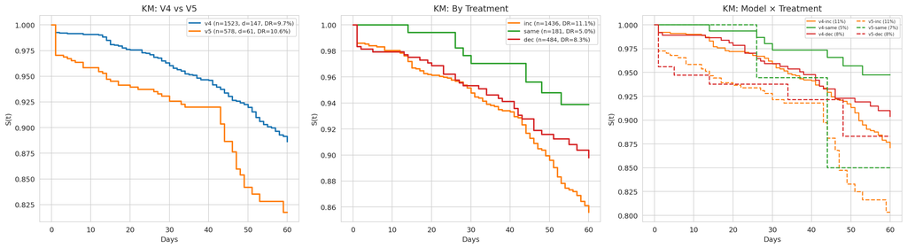

```
Log-rank V4 vs V5: chi2=14.519, p=0.0001 ***
```

```python
fig, axes = plt.subplots(1,3, figsize=(18,5))
for mf,c in [("v4","C0"),("v5","C1")]:
    s=us[us["model_family"]==mf]; km=kaplan_meier(s["T"],s["defaulted"])
    axes[0].step(km["time"],km["survival"],where="post",lw=2,color=c,
                 label=f"{mf} (n={len(s)}, d={s['defaulted'].sum()}, DR={s['defaulted'].mean():.1%})")
axes[0].set(xlabel="Days",ylabel="S(t)",title="KM: V4 vs V5"); axes[0].legend()

for td,c in [("inc","C1"),("same","C2"),("dec","C3")]:
    s=us[us["treat_dir"]==td]; km=kaplan_meier(s["T"],s["defaulted"])
    axes[1].step(km["time"],km["survival"],where="post",lw=2,color=c,
                 label=f"{td} (n={len(s)}, DR={s['defaulted'].mean():.1%})")
axes[1].set(xlabel="Days",ylabel="S(t)",title="KM: By Treatment"); axes[1].legend()

# V4/V5 × treatment
for mf,ls in [("v4","-"),("v5","--")]:
    for td,c in [("inc","C1"),("same","C2"),("dec","C3")]:
        s=us[(us["model_family"]==mf)&(us["treat_dir"]==td)]
        if len(s)<10: continue
        km=kaplan_meier(s["T"],s["defaulted"])
        axes[2].step(km["time"],km["survival"],where="post",lw=1.5,color=c,ls=ls,
                     label=f"{mf}-{td} ({s['defaulted'].mean():.0%})")
axes[2].set(xlabel="Days",ylabel="S(t)",title="KM: Model × Treatment"); axes[2].legend(fontsize=6,ncol=2)
fig.tight_layout(); plt.show()

def logrank(T1,E1,T2,E2):
    d1=pd.DataFrame({"T":T1,"E":E1,"g":0}).dropna(); d2=pd.DataFrame({"T":T2,"E":E2,"g":1}).dropna()
    da=pd.concat([d1,d2]); ts=sorted(da.loc[da["E"]==1,"T"].unique())
    O1=E1e=V=0
    for t in ts:
        ar=da[da["T"]>=t]; n=len(ar); n1=(ar["g"]==0).sum()
        d=((ar["T"]==t)&(ar["E"]==1)).sum(); d1v=((ar["T"]==t)&(ar["E"]==1)&(ar["g"]==0)).sum()
        if n<2: continue
        e1=n1*d/n; O1+=d1v; E1e+=e1; V+=n1*(n-n1)*d*(n-d)/(n**2*(n-1))
    chi2=(O1-E1e)**2/V if V>0 else np.nan
    return chi2, 1-stats.chi2.cdf(chi2,1) if V>0 else np.nan
s4=us[us["is_v5"]==0]; s5=us[us["is_v5"]==1]
c2,p=logrank(s4["T"],s4["defaulted"],s5["T"],s5["defaulted"])
print(f"Log-rank V4 vs V5: chi2={c2:.3f}, p={p:.4f} {stars(p)}")
```

## Part 3. 离散时间 Hazard Model（主因果证据）

这一部分是主线。重点不是一个静态的 pooled `inc vs same` 比较，而是在 counting-process 框架下，观察 treatment path 与后续 hazard 的关联。

这里保留一个很重要的研究边界：

- 结果支持 **存在 treatment-induced causal component**；
- 但 treatment 仍是 coarse binary `is_inc`；
- 因而不应把这里写成“已精确识别纯因果效应”。

```python
# ── Counting process construction ──
anchor_dates = anchor[["user_id", "anchor_date", "model_family"]].copy()
ep = df_all.merge(anchor_dates, on="user_id", how="inner", suffixes=("", "_anc"))
ep["day"] = (ep["event_date"] - ep["anchor_date"]).dt.days
ep = ep[(ep["day"] >= 0) & (ep["day"] <= CFG["max_followup_days"])].copy()

# 这里默认 ep 已经过 maturity / label 口径处理.
ep["event_default"] = (ep["default"] > 0).astype(int)
ep = ep.sort_values(["user_id", "day", "first_done_date"])

EPS = 0.01
cp_rows = []

for uid, grp in ep.groupby("user_id"):
    grp = grp.sort_values(["day", "first_done_date"]).reset_index(drop=True)
    n = len(grp)
    eff = np.empty(n, dtype=float)

    for idx in range(n):
        d = grp.iloc[idx]["day"]
        K = (grp["day"] == d).sum()
        k = (grp["day"] == d).iloc[: idx + 1].sum() - 1
        eff[idx] = d + (k + 1) / (K + 1)

    for idx in range(n):
        eff[idx] = max(eff[idx], EPS) if idx == 0 else max(eff[idx], eff[idx - 1] + EPS)

    for i in range(n):
        row = grp.iloc[i]
        start = eff[i - 1] if i > 0 else 0.0
        stop = eff[i]
        ev = int(row["event_default"] == 1)
        cp_rows.append(
            {
                "user_id": uid,
                "interval_idx": i,
                "start": start,
                "stop": stop,
                "event": ev,
                "is_v5": int(row["model_family_anc"] == "v5"),
                "tv_is_inc": int(row["is_inc"]),
                "tv_is_dec": int(row["is_dec"]),
                "tv_score_v4": row["score_v4"],
                "tv_score_v5": row["score_v5"],
            }
        )
        if ev == 1:
            break

cp = pd.DataFrame(cp_rows)
cp["t_mid"] = (cp["start"] + cp["stop"]) / 2
cp["t_mid_sq"] = cp["t_mid"] ** 2

feat_inter_in_ep = [f for f in CFG["feat_inter"] if f in ep.columns and ep[f].notna().any()]
ep_feats = ep[["user_id"] + feat_inter_in_ep].copy()
ep_feats["_rank"] = ep_feats.groupby("user_id").cumcount()
cp["_rank"] = cp.groupby("user_id").cumcount()
cp = cp.merge(ep_feats, on=["user_id", "_rank"], how="left", suffixes=("", "_ep"))
feat_in_cp = [f for f in feat_inter_in_ep if f in cp.columns]

risk_oof, risk_auc, risk_std, _ = xgb_crossfit(
    cp, feat_in_cp, "event", CFG, group_col="user_id"
)
cp["risk_ml"] = risk_oof

for c in ["tv_score_v4", "tv_score_v5", "risk_ml"]:
    if c in cp.columns:
        cp[c] = cp[c].fillna(cp[c].median())

print(f"CP: {len(cp)} intervals, {cp['user_id'].nunique()} users, {cp['event'].sum()} defaults")
print(f"Event-level risk score AUC: {risk_auc:.4f}±{risk_std:.4f}")
print(f"Features in CP: {len(feat_in_cp)}")
```

```
CP: 10317 intervals, 2104 users, 211 defaults
Event-level risk score AUC: 0.6128±0.0291
Features in CP: 803
```

```python
# ── Hazard models: without and with HD X control ──
print("="*75)
print("  HAZARD MODELS (paired: without / with HD X control)")
print("="*75)

m_noX=smf.glm("event ~ t_mid + t_mid_sq + tv_is_inc + tv_is_dec + is_v5",
               data=cp,family=sm.families.Binomial()).fit(
    cov_type="cluster",cov_kwds={"groups":cp["user_id"]})
stata_table(m_noX, "Hazard A (no HD X): time + treatment + is_v5")

m_X=smf.glm("event ~ t_mid + t_mid_sq + risk_ml + tv_is_inc + tv_is_dec + is_v5",
             data=cp.dropna(subset=["risk_ml"]),family=sm.families.Binomial()).fit(
    cov_type="cluster",cov_kwds={"groups":cp.dropna(subset=["risk_ml"])["user_id"]})
stata_table(m_X, "Hazard B (+ HD risk_ml): controlling for X_t")

# Score controls variant
m_scores=smf.glm("event ~ t_mid + t_mid_sq + tv_score_v4 + tv_score_v5 + tv_is_inc + tv_is_dec + is_v5",
                  data=cp,family=sm.families.Binomial()).fit(
    cov_type="cluster",cov_kwds={"groups":cp["user_id"]})
stata_table(m_scores, "Hazard C (+ sv4 + sv5): score controls")

# Summary comparison
print(f"\n{'─'*75}")
print(f"  Coefficient stability across specifications")
print(f"{'─'*75}")
print(f"  {'Spec':<20} {'tv_is_inc':>12} {'tv_is_dec':>12} {'is_v5':>12}")
print(f"  {'─'*58}")
for name,m in [("A: no HD X",m_noX),("B: + risk_ml",m_X),("C: + scores",m_scores)]:
    vals=[]
    for v in ["tv_is_inc","tv_is_dec","is_v5"]:
        c=m.params.get(v,np.nan); p=m.pvalues.get(v,np.nan)
        vals.append(f"{c:>+.3f}{stars(p)}")
    print(f"  {name:<20} {'  '.join(vals)}")
```

```
===========================================================================
  HAZARD MODELS (paired: without / with HD X control)
===========================================================================

───────────────────────────────────────────────────────────────────────────
  Hazard A (no HD X): time + treatment + is_v5
───────────────────────────────────────────────────────────────────────────
  ........................     Coef.   Std.Err.        z    P>|z|              [95% CI]
───────────────────────────────────────────────────────────────────────────
  Intercept...............   -4.8544     0.2015   -24.09   0.0000  [ -5.2493,  -4.4595] ***
  t_mid...................    0.0380     0.0136     2.80   0.0051  [  0.0114,   0.0646] ***
  t_mid_sq................   -0.0004     0.0003    -1.40   0.1627  [ -0.0008,   0.0001]
  tv_is_inc...............    0.3787     0.1766     2.14   0.0321  [  0.0325,   0.7249] **
  tv_is_dec...............    0.4577     0.1976     2.32   0.0206  [  0.0703,   0.8450] **
  is_v5...................    0.4407     0.1574     2.80   0.0051  [  0.1322,   0.7491] ***
───────────────────────────────────────────────────────────────────────────
  N = 10,317   AIC = 2038.6
  * p<0.10, ** p<0.05, *** p<0.01

───────────────────────────────────────────────────────────────────────────
  Hazard B (+ HD risk_ml): controlling for X_t
───────────────────────────────────────────────────────────────────────────
  ........................     Coef.   Std.Err.        z    P>|z|              [95% CI]
───────────────────────────────────────────────────────────────────────────
  Intercept...............   -5.4690     0.2310   -23.67   0.0000  [ -5.9218,  -5.0162] ***
  t_mid...................    0.0347     0.0136     2.55   0.0108  [  0.0080,   0.0614] **
  t_mid_sq................   -0.0003     0.0003    -1.17   0.2434  [ -0.0008,   0.0002]
  risk_ml.................   29.0688     5.4093     5.37   0.0000  [ 18.4668,  39.6708] ***
  tv_is_inc...............    0.3682     0.1775     2.07   0.0381  [  0.0202,   0.7161] **
  tv_is_dec...............    0.4483     0.1986     2.26   0.0240  [  0.0591,   0.8374] **
  is_v5...................    0.4710     0.1582     2.98   0.0029  [  0.1610,   0.7811] ***
───────────────────────────────────────────────────────────────────────────
  N = 10,317   AIC = 2019.2
  * p<0.10, ** p<0.05, *** p<0.01

───────────────────────────────────────────────────────────────────────────
  Hazard C (+ sv4 + sv5): score controls
───────────────────────────────────────────────────────────────────────────
  ........................     Coef.   Std.Err.        z    P>|z|              [95% CI]
───────────────────────────────────────────────────────────────────────────
  Intercept...............   -5.7700     0.2647   -21.80   0.0000  [ -6.2888,  -5.2513] ***
  t_mid...................    0.0374     0.0135     2.77   0.0055  [  0.0110,   0.0638] ***
  t_mid_sq................   -0.0003     0.0003    -1.29   0.1967  [ -0.0008,   0.0002]
  tv_score_v4.............    0.4288     0.9691     0.44   0.6582  [ -1.4706,   2.3282]
  tv_score_v5.............    3.8423     0.9191     4.18   0.0000  [  2.0409,   5.6437] ***
  tv_is_inc...............    0.2931     0.1769     1.66   0.0976  [ -0.0536,   0.6398] *
  tv_is_dec...............    0.2880     0.1995     1.44   0.1489  [ -0.1030,   0.6791]
  is_v5...................    0.4240     0.1569     2.70   0.0069  [  0.1166,   0.7314] ***
───────────────────────────────────────────────────────────────────────────
  N = 10,317   AIC = 1995.4
  * p<0.10, ** p<0.05, *** p<0.01

───────────────────────────────────────────────────────────────────────────
  Coefficient stability across specifications
───────────────────────────────────────────────────────────────────────────
  Spec                    tv_is_inc    tv_is_dec        is_v5
  ──────────────────────────────────────────────────────────
  A: no HD X           +0.379**  +0.458**  +0.441***
  B: + risk_ml         +0.368**  +0.448**  +0.471***
  C: + scores          +0.293*  +0.288  +0.424***
```

## Part 4. 事件级 IPTW：Conditional vs MSM 一致性检查

这一部分的作用是检验方向稳健性，而不是把 MSM 结果写成比主 hazard 模型更“正式”的主结论。

```python
FEAT_AVAIL = {}
for name, flist in [
    ("X_v4", CFG["feat_v4"]),
    ("X_v5", CFG["feat_v5"]),
    ("X_inter", CFG["feat_inter"]),
    ("X_union", CFG["feat_union"]),
]:
    FEAT_AVAIL[name] = [f for f in flist if f in cp.columns and cp[f].notna().any()]

ps_res = {}
for fs, fl in FEAT_AVAIL.items():
    if len(fl) < 10:
        continue
    oof, auc, std, nf = xgb_crossfit(cp, fl, "tv_is_inc", CFG, group_col="user_id")
    ps_res[fs] = oof
    cp[f"ps_{fs}"] = oof
    print(f"{fs}: {nf} feats, PS AUC={auc:.4f}±{std:.4f}")

num_mod = smf.glm("tv_is_inc ~ t_mid + is_v5", data=cp, family=sm.families.Binomial()).fit()
ps_num = num_mod.predict(cp).clip(0.01, 0.99)

msm_res = {}
for fs in ps_res:
    pd_ = np.clip(cp[f"ps_{fs}"].values, 0.02, 0.98)
    pd_ = np.where(np.isnan(pd_), 0.5, pd_)
    w = np.where(cp["tv_is_inc"].values == 1, ps_num.values / pd_, (1 - ps_num.values) / (1 - pd_))
    lo, hi = np.percentile(w, [1, 99])
    w = np.clip(w, lo, hi)
    m = smf.glm(
        "event ~ t_mid + t_mid_sq + tv_is_inc + tv_is_dec + is_v5",
        data=cp,
        family=sm.families.Binomial(),
        freq_weights=w,
    ).fit(cov_type="HC1")
    msm_res[fs] = m

print(f"\n{'─'*75}")
print("  Cond (Hazard B) vs MSM: direction check only")
print(f"{'─'*75}")
n_agree = 0
n_total = 0
for var in ["tv_is_inc", "tv_is_dec", "is_v5"]:
    cc = m_X.params.get(var, np.nan)
    print(f"\n  {var}: Cond = {cc:+.4f} (p={m_X.pvalues.get(var, np.nan):.4f})")
    for fs, mm in msm_res.items():
        mc = mm.params.get(var, np.nan)
        mp = mm.pvalues.get(var, np.nan)
        ok = "✓" if cc * mc > 0 else "✗"
        if cc * mc > 0:
            n_agree += 1
        n_total += 1
        print(f"    MSM-{fs:<8}: {mc:+.4f} (p={mp:.4f}) {stars(mp)} {ok}")
print(f"\n  Direction agreement: {n_agree}/{n_total}")
```

```
X_v4: 803 feats, PS AUC=0.7598±0.0073
X_v5: 803 feats, PS AUC=0.7605±0.0065
X_inter: 803 feats, PS AUC=0.7578±0.0037
X_union: 803 feats, PS AUC=0.7578±0.0037

───────────────────────────────────────────────────────────────────────────
  Cond (Hazard B) vs MSM: direction check only
───────────────────────────────────────────────────────────────────────────

  tv_is_inc: Cond = +0.3682 (p=0.0381)
    MSM-X_v4    : +0.3907 (p=0.0315) ** ✓
    MSM-X_v5    : +0.3583 (p=0.0464) ** ✓
    MSM-X_inter : +0.3346 (p=0.0637) * ✓
    MSM-X_union : +0.3346 (p=0.0637) * ✓

  tv_is_dec: Cond = +0.4483 (p=0.0240)
    MSM-X_v4    : +0.5328 (p=0.0070) *** ✓
    MSM-X_v5    : +0.5116 (p=0.0089) *** ✓
    MSM-X_inter : +0.4955 (p=0.0115) ** ✓
    MSM-X_union : +0.4955 (p=0.0115) ** ✓

  is_v5: Cond = +0.4710 (p=0.0029)
    MSM-X_v4    : +0.5149 (p=0.0009) *** ✓
    MSM-X_v5    : +0.5070 (p=0.0011) *** ✓
    MSM-X_inter : +0.5445 (p=0.0005) *** ✓
    MSM-X_union : +0.5445 (p=0.0005) *** ✓

  Direction agreement: 12/12
```

## Part 5–8. Selection 识别链

这一部分围绕三个问题展开：

1. **谁被更容易推向 `inc`？**
2. **这些被额外推入 `inc` 的用户，本来是否更危险？**
3. **selection 可能通过哪些 `X` 维度实现？**

注意：这里的 selection 诊断仍然主要是 **directional / diagnostic**，不是正式点识别。

```
===========================================================================
  SELECTION STEP 1: WHO IS PUSHED TOWARD INC?
===========================================================================
```

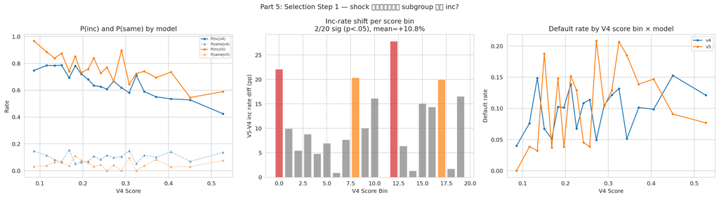

```
V5 inc users: 436
Estimated excess users (sum of cell-level excess shares): 88.4
Mean V5-V4 inc-rate diff by V4-score bin: +0.1084
Share of 2D cells with positive push_diff: 74.0%
```

```python
print("="*75)
print("  SELECTION STEP 1: WHO IS PUSHED TOWARD INC?")
print("="*75)

# 1D mapping by V4 score bin
n_bins = 20
us["sv4_bin"] = safe_qcut_rank(us["score_v4"], q=n_bins, labels=False)

test_rows = []
mapping = []

for b in sorted(us["sv4_bin"].dropna().unique()):
    sub = us[us["sv4_bin"] == b]
    for mf in ["v4", "v5"]:
        s = sub[sub["model_family"] == mf]
        if len(s) < 3:
            continue
        mapping.append(
            dict(
                sv4_bin=b,
                sv4_mean=sub["score_v4"].mean(),
                model=mf,
                inc_rate=s["is_inc"].mean(),
                same_rate=(s["treat_dir"] == "same").mean(),
                dec_rate=s["is_dec"].mean(),
                def_rate=s["defaulted"].mean(),
                n=len(s),
            )
        )
    g4 = sub[sub["model_family"] == "v4"]["is_inc"]
    g5 = sub[sub["model_family"] == "v5"]["is_inc"]
    if len(g4) < 3 or len(g5) < 3:
        continue
    tbl = np.array([[g4.sum(), len(g4) - g4.sum()], [g5.sum(), len(g5) - g5.sum()]])
    _, pf = stats.fisher_exact(tbl)
    test_rows.append(
        dict(
            bin=b,
            sv4=sub["score_v4"].mean(),
            diff=g5.mean() - g4.mean(),
            p=pf,
            n_v4=len(g4),
            n_v5=len(g5),
        )
    )

tdf = pd.DataFrame(test_rows)
mdf_ = pd.DataFrame(mapping)
n_sig = (tdf["p"] < 0.05).sum()
mean_diff = tdf["diff"].mean()

fig, axes = plt.subplots(1, 3, figsize=(18, 5))
ax = axes[0]
for mf, c in [("v4", "C0"), ("v5", "C1")]:
    sub = mdf_[mdf_["model"] == mf]
    ax.plot(sub["sv4_mean"], sub["inc_rate"], "o-", color=c, label=f"P(inc|{mf})", ms=3, lw=1.5)
    ax.plot(sub["sv4_mean"], sub["same_rate"], "^--", color=c, label=f"P(same|{mf})", ms=3, lw=1, alpha=.5)
ax.set(xlabel="V4 Score", ylabel="Rate", title="P(inc) and P(same) by model")
ax.legend(fontsize=6)

ax = axes[1]
colors_ = ["C3" if p < 0.05 else "C1" if p < 0.1 else "C7" for p in tdf["p"]]
ax.bar(tdf["bin"], tdf["diff"] * 100, color=colors_, alpha=.7)
ax.axhline(0, c="k", lw=.5)
ax.set(
    xlabel="V4 Score Bin",
    ylabel="V5-V4 inc rate diff (pp)",
    title=f"Inc-rate shift per score bin\n{n_sig}/{len(tdf)} sig (p<.05), mean={mean_diff:+.1%}",
)

ax = axes[2]
for mf, c in [("v4", "C0"), ("v5", "C1")]:
    sub = mdf_[mdf_["model"] == mf]
    ax.plot(sub["sv4_mean"], sub["def_rate"], "o-", color=c, label=mf, ms=3)
ax.set(xlabel="V4 Score", ylabel="Default rate", title="Default rate by V4 score bin × model")
ax.legend()
fig.suptitle("Part 5: Selection Step 1 — shock 主要把哪些局部 subgroup 推向 inc?", fontsize=12)
fig.tight_layout()
plt.show()

# 2D push mapping: V4-score decile × baseline-credit quintile
us["sv4_d10"] = safe_qcut_rank(us["score_v4"], q=10, labels=False)
us["cred_q5"] = safe_qcut_rank(us["first_bf_credit"], q=5, labels=False)
us["cell_q"] = us["sv4_d10"].astype(str) + "_" + us["cred_q5"].astype(str)

cell_v4 = us[us["is_v5"] == 0].groupby("cell_q").agg(v4_inc_rate=("is_inc", "mean"), n_v4=("user_id", "size")).reset_index()
cell_v5 = us[us["is_v5"] == 1].groupby("cell_q").agg(v5_inc_rate=("is_inc", "mean"), n_v5=("user_id", "size")).reset_index()
cell_map = cell_v4.merge(cell_v5, on="cell_q", how="outer").fillna({"v4_inc_rate": 0, "v5_inc_rate": 0, "n_v4": 0, "n_v5": 0})
cell_map["push_diff"] = cell_map["v5_inc_rate"] - cell_map["v4_inc_rate"]
cell_map["push_diff_pos"] = cell_map["push_diff"].clip(lower=0)
cell_map["excess_share"] = np.where(
    cell_map["v5_inc_rate"] > 0,
    cell_map["push_diff_pos"] / cell_map["v5_inc_rate"].clip(lower=1e-6),
    0,
).clip(0, 1)

us = us.merge(cell_map[["cell_q", "v4_inc_rate", "v5_inc_rate", "push_diff", "excess_share"]], on="cell_q", how="left")

v5_inc = us[(us["is_v5"] == 1) & (us["is_inc"] == 1)].copy()
v5_inc["excess_prob"] = v5_inc["excess_share"].fillna(0)
thr = max(v5_inc["excess_prob"].quantile(0.75), 1e-8)
v5_inc["inc_type"] = np.where(v5_inc["excess_prob"] >= thr, "likely_excess", "likely_natural")

print(f"\nV5 inc users: {len(v5_inc)}")
print(f"Estimated excess users (sum of cell-level excess shares): {v5_inc['excess_prob'].sum():.1f}")
print(f"Mean V5-V4 inc-rate diff by V4-score bin: {mean_diff:+.4f}")
print(f"Share of 2D cells with positive push_diff: {(cell_map['push_diff'] > 0).mean():.1%}")
```

```
===========================================================================
  SELECTION STEP 2: ARE THE PUSHED USERS INHERENTLY RISKIER?
===========================================================================
  注: 这一部分只提供方向性 selection 诊断, 不是正式识别。
  likely_natural: n=316, sv4=0.2414, sv5=0.1990, gap=+0.0424, credit=48647, DEFAULT=10.4%, excess_prob=0.120
  likely_excess: n=120, sv4=0.3097, sv5=0.2337, gap=+0.0761, credit=60986, DEFAULT=14.2%, excess_prob=0.422

  Fisher (excess vs natural): OR=1.42, p=0.3126
  Risk-difference (excess - natural): +3.72%  95% CI [-3.37%, +10.82%]
```

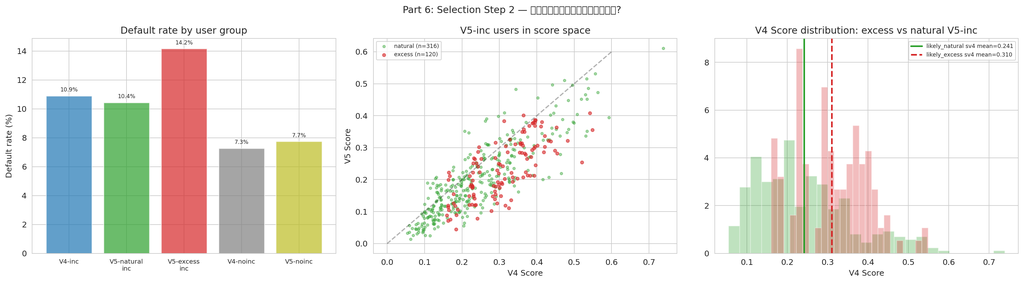

```
--- Regression: within V5-inc users, does excess_prob predict default? (directional only) ---

───────────────────────────────────────────────────────────────────────────
  V5-inc: default ~ excess_prob + scores [directional diagnostic]
───────────────────────────────────────────────────────────────────────────
  ........................     Coef.   Std.Err.        z    P>|z|              [95% CI]
───────────────────────────────────────────────────────────────────────────
  Intercept...............   -2.7212     0.3499    -7.78   0.0000  [ -3.4070,  -2.0354] ***
  excess_prob.............    1.0971     1.0158     1.08   0.2802  [ -0.8939,   3.0881]
  score_v4................   -3.7163     2.9267    -1.27   0.2042  [ -9.4525,   2.0199]
  score_v5................    6.4606     2.9972     2.16   0.0311  [  0.5862,  12.3350] **
───────────────────────────────────────────────────────────────────────────
  N = 436   AIC = 309.6
  * p<0.10, ** p<0.05, *** p<0.01

───────────────────────────────────────────────────────────────────────────
  V5-inc: default ~ excess_prob + risk_ml [directional diagnostic]
───────────────────────────────────────────────────────────────────────────
  ........................     Coef.   Std.Err.        z    P>|z|              [95% CI]
───────────────────────────────────────────────────────────────────────────
  Intercept...............   -1.7618     0.5032    -3.50   0.0005  [ -2.7481,  -0.7756] ***
  excess_prob.............    0.8818     0.8837     1.00   0.3184  [ -0.8503,   2.6139]
  risk_ml.................   -4.9593     4.6837    -1.06   0.2897  [-14.1392,   4.2205]
───────────────────────────────────────────────────────────────────────────
  N = 436   AIC = 314.5
  * p<0.10, ** p<0.05, *** p<0.01
```

```python
print("="*75)
print("  SELECTION STEP 2: ARE THE PUSHED USERS INHERENTLY RISKIER?")
print("="*75)
print("  注: 这一部分只提供方向性 selection 诊断, 不是正式识别。")

for it in ["likely_natural", "likely_excess"]:
    s = v5_inc[v5_inc["inc_type"] == it]
    print(
        f"  {it}: n={len(s)}, sv4={s['score_v4'].mean():.4f}, sv5={s['score_v5'].mean():.4f}, "
        f"gap={s['gap_raw'].mean():+.4f}, credit={s['first_bf_credit'].mean():.0f}, "
        f"DEFAULT={s['defaulted'].mean():.1%}, excess_prob={s['excess_prob'].mean():.3f}"
    )

e_d = v5_inc[v5_inc["inc_type"] == "likely_excess"]["defaulted"]
n_d = v5_inc[v5_inc["inc_type"] == "likely_natural"]["defaulted"]
tbl = np.array([[e_d.sum(), len(e_d) - e_d.sum()], [n_d.sum(), len(n_d) - n_d.sum()]])
orf, pf = stats.fisher_exact(tbl)
rd, rd_lo, rd_hi = rd_ci(e_d, n_d)

print(f"\n  Fisher (excess vs natural): OR={orf:.2f}, p={pf:.4f} {stars(pf)}")
print(f"  Risk-difference (excess - natural): {rd:+.2%}  95% CI [{rd_lo:+.2%}, {rd_hi:+.2%}]")

# five-group descriptive comparison
v4i = us[(us["is_v5"] == 0) & (us["is_inc"] == 1)]
v4n = us[(us["is_v5"] == 0) & (us["is_inc"] == 0)]
v5n = us[(us["is_v5"] == 1) & (us["is_inc"] == 0)]
e_ = v5_inc[v5_inc["inc_type"] == "likely_excess"]
n__ = v5_inc[v5_inc["inc_type"] == "likely_natural"]

fig, axes = plt.subplots(1, 3, figsize=(18, 5))

ax = axes[0]
groups = ["V4-inc", "V5-natural\ninc", "V5-excess\ninc", "V4-noinc", "V5-noinc"]
rates = [v4i["defaulted"].mean(), n__["defaulted"].mean(), e_["defaulted"].mean(), v4n["defaulted"].mean(), v5n["defaulted"].mean()]
colors_ = ["C0", "C2", "C3", "C7", "C8"]
ax.bar(range(len(groups)), [r * 100 for r in rates], color=colors_, alpha=.7)
ax.set_xticks(range(len(groups)))
ax.set_xticklabels(groups, fontsize=8)
for i, r in enumerate(rates):
    ax.text(i, r * 100 + 0.3, f"{r:.1%}", ha="center", fontsize=7)
ax.set(ylabel="Default rate (%)", title="Default rate by user group")

ax = axes[1]
ax.scatter(n__["score_v4"], n__["score_v5"], s=10, alpha=.4, c="C2", label=f"natural (n={len(n__)})")
ax.scatter(e_["score_v4"], e_["score_v5"], s=15, alpha=.6, c="C3", label=f"excess (n={len(e_)})")
ax.plot([0, .6], [0, .6], "k--", alpha=.3)
ax.set(xlabel="V4 Score", ylabel="V5 Score", title="V5-inc users in score space")
ax.legend(fontsize=7)

ax = axes[2]
for it, c, ls in [("likely_natural", "C2", "-"), ("likely_excess", "C3", "--")]:
    sub = v5_inc[v5_inc["inc_type"] == it]
    ax.hist(sub["score_v4"], bins=25, alpha=.3, density=True, color=c)
    ax.axvline(sub["score_v4"].mean(), color=c, ls=ls, lw=2, label=f"{it} sv4 mean={sub['score_v4'].mean():.3f}")
ax.set(xlabel="V4 Score", title="V4 Score distribution: excess vs natural V5-inc")
ax.legend(fontsize=7)
fig.suptitle("Part 6: Selection Step 2 — 被额外推入的用户本来是否更危险?", fontsize=12)
fig.tight_layout()
plt.show()

print("\n--- Regression: within V5-inc users, does excess_prob predict default? (directional only) ---")
v5_inc["risk_ml"] = us.loc[v5_inc.index, "risk_ml"].values
m_noX = smf.glm(
    "defaulted ~ excess_prob + score_v4 + score_v5",
    data=v5_inc,
    family=sm.families.Binomial(),
).fit(cov_type="HC1")
stata_table(m_noX, "V5-inc: default ~ excess_prob + scores [directional diagnostic]")

m_wX = smf.glm(
    "defaulted ~ excess_prob + risk_ml",
    data=v5_inc.dropna(subset=["risk_ml"]),
    family=sm.families.Binomial(),
).fit(cov_type="HC1")
stata_table(m_wX, "V5-inc: default ~ excess_prob + risk_ml [directional diagnostic]")
```

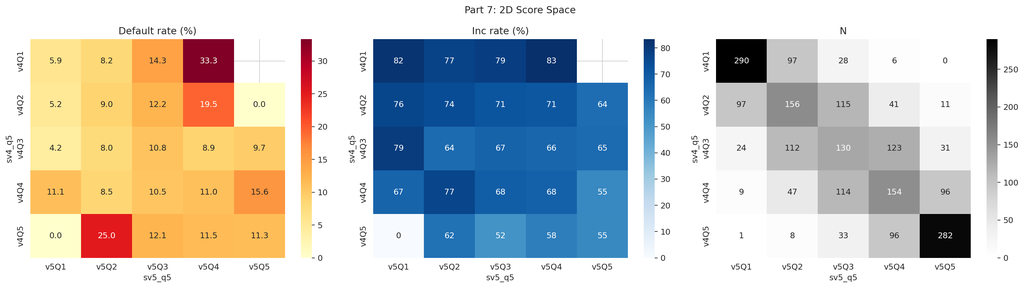

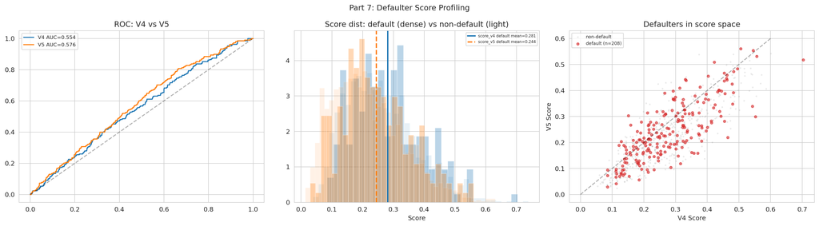

```
=== Default Rate: Model × Treatment ===
  ..........      inc     same      dec      all
  v4........   10.9%    4.6%    8.4%    9.7%
  v5........   11.5%    7.1%    7.9%   10.6%
```

```python
# 7.1: 2D heatmaps
us["sv4_q5"]=pd.qcut(us["score_v4"].rank(method="first"),q=5,labels=["v4Q1","v4Q2","v4Q3","v4Q4","v4Q5"])
us["sv5_q5"]=pd.qcut(us["score_v5"].rank(method="first"),q=5,labels=["v5Q1","v5Q2","v5Q3","v5Q4","v5Q5"])
dr_2d=us.pivot_table(values="defaulted",index="sv4_q5",columns="sv5_q5",aggfunc="mean")
inc_2d=us.pivot_table(values="is_inc",index="sv4_q5",columns="sv5_q5",aggfunc="mean")
n_2d=us.pivot_table(values="defaulted",index="sv4_q5",columns="sv5_q5",aggfunc="count")

fig,axes=plt.subplots(1,3,figsize=(18,5))
sns.heatmap(dr_2d*100,annot=True,fmt=".1f",cmap="YlOrRd",ax=axes[0]); axes[0].set_title("Default rate (%)")
sns.heatmap(inc_2d*100,annot=True,fmt=".0f",cmap="Blues",ax=axes[1]); axes[1].set_title("Inc rate (%)")
sns.heatmap(n_2d,annot=True,fmt="d",cmap="Greys",ax=axes[2]); axes[2].set_title("N")
fig.suptitle("Part 7: 2D Score Space",fontsize=12); fig.tight_layout(); plt.show()

# 7.2: Defaulter profiling
fig,axes=plt.subplots(1,3,figsize=(18,5))
# ROC overlay
ax=axes[0]
for col,lab,c in [("score_v4","V4","C0"),("score_v5","V5","C1")]:
    fpr,tpr,_=roc_curve(us["defaulted"],us[col])
    auc=roc_auc_score(us["defaulted"],us[col])
    ax.plot(fpr,tpr,color=c,label=f"{lab} AUC={auc:.3f}",lw=1.5)
ax.plot([0,1],[0,1],"k--",alpha=.3); ax.set(title="ROC: V4 vs V5"); ax.legend()

# Score distributions by default status (overlaid)
ax=axes[1]
for col,c,ls in [("score_v4","C0","-"),("score_v5","C1","--")]:
    d=us.loc[us["defaulted"]==1,col]; nd=us.loc[us["defaulted"]==0,col]
    ax.hist(d,bins=30,alpha=.3,density=True,color=c); ax.hist(nd,bins=40,alpha=.1,density=True,color=c)
    ax.axvline(d.mean(),color=c,ls=ls,lw=2,label=f"{col} default mean={d.mean():.3f}")
ax.set(xlabel="Score",title="Score dist: default (dense) vs non-default (light)"); ax.legend(fontsize=6)

# Defaulters in score space
ax=axes[2]
nd_s=us[us["defaulted"]==0].sample(min(500,len(us[us["defaulted"]==0])),random_state=42)
ax.scatter(nd_s["score_v4"],nd_s["score_v5"],s=3,alpha=.1,c="C7",label="non-default")
d_=us[us["defaulted"]==1]
ax.scatter(d_["score_v4"],d_["score_v5"],s=15,alpha=.6,c="C3",label=f"default (n={len(d_)})")
ax.plot([0,.6],[0,.6],"k--",alpha=.3)
ax.set(xlabel="V4 Score",ylabel="V5 Score",title="Defaulters in score space"); ax.legend(fontsize=7)
fig.suptitle("Part 7: Defaulter Score Profiling",fontsize=12); fig.tight_layout(); plt.show()

# Model family × treatment crosstab
print("\n=== Default Rate: Model × Treatment ===")
print(f"  {'':.<10} {'inc':>8} {'same':>8} {'dec':>8} {'all':>8}")
for mf in ["v4","v5"]:
    row=f"  {mf:.<10}"
    for td in ["inc","same","dec","all"]:
        s=us[(us["model_family"]==mf)&(us["treat_dir"]==td)] if td!="all" else us[us["model_family"]==mf]
        row+=f" {s['defaulted'].mean():>7.1%}"
    print(row)
```

```python
print("="*75)
print("  SELECTION STEP 3: THROUGH WHICH X DOES SELECTION OPERATE?")
print("="*75)
print("  注: 这部分是 exploratory feature diagnostics, 用于说明可能渠道, 不是正式识别。")

feat_avail = [f for f in CFG["feat_inter"] if f in v5_inc.columns and v5_inc[f].notna().any()]
print(f"Features available: {len(feat_avail)}")

X_prof = v5_inc[feat_avail].values.astype(np.float32)
y_prof = (v5_inc["inc_type"] == "likely_excess").astype(int).values
dt = xgb.DMatrix(X_prof, label=y_prof, feature_names=feat_avail, missing=np.nan)

params = {
    "objective": "binary:logistic",
    "max_depth": 3,
    "learning_rate": 0.05,
    "subsample": 0.8,
    "colsample_bytree": 0.6,
    "min_child_weight": 10,
    "device": CFG["xgb_device"],
    "verbosity": 0,
}
bst_prof = xgb.train(params, dt, num_boost_round=100, verbose_eval=False)
imp = pd.Series(bst_prof.get_score(importance_type="gain")).sort_values(ascending=False)

print("\n=== Top 15 features: excess vs natural V5-inc users (exploratory) ===")
print(f"  {'Feature':<50} {'Gain':>6} {'Excess':>9} {'Natural':>9}")
print("  " + "─" * 78)
for f, v in imp.head(15).items():
    em = v5_inc.loc[v5_inc["inc_type"] == "likely_excess", f].mean()
    nm = v5_inc.loc[v5_inc["inc_type"] == "likely_natural", f].mean()
    print(f"  {f:<50} {v:>6.1f} {em:>9.4f} {nm:>9.4f}")
```

```
===========================================================================
  SELECTION STEP 3: THROUGH WHICH X DOES SELECTION OPERATE?
===========================================================================
  注: 这部分是 exploratory feature diagnostics, 用于说明可能渠道, 不是正式识别。
Features available: 803

=== Top 15 features: excess vs natural V5-inc users (exploratory) ===
  Feature                                              Gain    Excess   Natural
  ──────────────────────────────────────────────────────────────────────────────
  PHI_REPAYMENT_PRESSURE___afterFeatureVO___allOrder6M___internalAndExternalLiabilitiesResultVO___ratioUncompletedAmountAndMIncome   25.7    1.1322    1.5877
  PHI_REPAYMENT_PRESSURE___afterFeatureVO___allOrder3M___internalAndExternalLiabilitiesResultVO___ratioUncompletedAmountAndMIncome   17.3    0.9437    1.4869
  PHI_SMS_PATTERN_CATEGORY_V6___features___patternCategoryUnknownV6UnreadLast30DCount   17.3  158.9157  112.5019
  PHI_REPAYMENT_PAY_DAY___last120DStat___maxSingleDayRepayAmountToNoRepayRatio   16.9    0.2455    0.4060
  PHI_BEHAVIOR_ORDER_AND_INSTALLMENT___behaviorOrderAndInstallmentAllDays___aheadCompleteBillDaysRatio___max   14.7    2.3156    3.5618
  PHI_REPAYMENT_PAY_DAY___last60DStat___maxSingleDayAdvanceRepayAmountToNoRepayRatio   14.4    0.1943    0.3615
  PHI_REPAYMENT_PAY_DAY___last30DStat___maxSingleDayRepayAmountToNoRepayRatio   13.0    0.1874    0.3318
  PHI_WITHDRAW_FEATURE_V2___recentHistoryLast3MonthOrderV2RiskVO___avgCreditsUsageRecentMonths   12.8    0.5427    0.4279
  PHI_REPAYMENT_PRESSURE___preFeatureVO___allOrder1M___internalLiabilitiesResultVO___ratioCompletedAmountAndCompletedAdAmount   12.8    1.5387    1.3509
  PHI_BEHAVIOR_ORDER_AND_INSTALLMENT___behaviorOrderAndInstallmentAllDays___orderCompletedRatio___min   12.4    0.0391    0.0779
  PHI_ORDER_INFO_FOR_MULTI_LOAN___toRepay30DaysOverUnCompletedRatio   11.7    0.6133    1.3057
  PHI_APP_CATEGORY_TIME_GAP_V1___features___categoryTimeGapAvgUpdateV1NoSysTOOLS   11.7 47544918920.5514 44780796757.3119
  PHI_WOE_5CV_APP___features___d3_amt_woe_avg_d14NoSysInstallShardingTotal   11.6   -0.2191   -0.2057
  PHI_APP_TIME_GAP_V1___features___lastUpdateDaysTopV1F22   11.5    8.1142    6.8221
  PHI_REPAYMENT_PRESSURE___afterFeatureVO___inLoanOrder6M___internalAndExternalLiabilitiesResultVO___ratioUncompletedAmountAndMIncome   11.3    1.1322    1.5877
```

```python
# 8.2: 哪些特征区分 V5-inc vs V4-inc (同一 inc 组内的 assignment shift)
all_inc = us[us["is_inc"] == 1].copy()
X_policy = all_inc[feat_avail].values.astype(np.float32)
y_policy = all_inc["is_v5"].values
dt2 = xgb.DMatrix(X_policy, label=y_policy, feature_names=feat_avail, missing=np.nan)
bst_pol = xgb.train(params, dt2, num_boost_round=100, verbose_eval=False)
imp_pol = pd.Series(bst_pol.get_score(importance_type="gain")).sort_values(ascending=False)

print("\n=== Top 15 features: V5-inc vs V4-inc users (assignment shift, exploratory) ===")
print(f"  {'Feature':<50} {'Gain':>6} {'V5-inc':>9} {'V4-inc':>9}")
print("  " + "─" * 78)
for f, v in imp_pol.head(15).items():
    v5m = all_inc.loc[all_inc["is_v5"] == 1, f].mean()
    v4m = all_inc.loc[all_inc["is_v5"] == 0, f].mean()
    print(f"  {f:<50} {v:>6.1f} {v5m:>9.4f} {v4m:>9.4f}")

top_excess = set(imp.head(20).index)
top_policy = set(imp_pol.head(20).index)
overlap_feats = top_excess & top_policy
print(f"\n=== Feature overlap (top 20 each): {len(overlap_feats)} shared ===")
for f in sorted(overlap_feats):
    print(f"  {f}")
print("\nInterpretation: shared dimensions are consistent with selection channels, but remain exploratory.")
```

```
=== Top 15 features: V5-inc vs V4-inc users (assignment shift, exploratory) ===
  Feature                                              Gain    V5-inc    V4-inc
  ──────────────────────────────────────────────────────────────────────────────
  PHI_APP_CATEGORY_TIME_GAP_V12___features___categoryDaysMaxInstallV12NoSysGuoJiaYiLiaoFuWu   46.7 1922.5317 1803.7653
  PHI_APP_CATEGORY_STAT_V12___features___categoryStatCntV12NoSysBNPL   24.6    9.5000    9.9609
  PHI_APP_CATEGORY_TIME_GAP_V12___features___categoryDaysMaxInstallV12NoSysd7_amt_person_cut_pos_upper_1   24.5 8334.3102 7597.5013
  PHI_BASIC_ORDER___daysSinceLastPayoutOrder           23.6   23.4033   17.6102
  PHI_APP_CATEGORY_TIME_GAP_V6___features___categoryHoursMaxInstallV6NoSystools   22.8 114278.5887 105536.5250
  PHI_APP_EMBEDDING_V1___features___embeddingSumV1NoSysF8   21.6  -65.8454  -69.2532
  PHI_APP_CATEGORY_TIME_GAP_V1___features___categoryDaysMaxInstallV1NoSysPHOTO   20.5 4342.2926 3699.7360
  PHI_SMS_KEY_WORD_TIME_DIFF_V1___features___keywordTimeDiffMaxV1Latest1000F4702   20.4  103.7524   98.6129
  PHI_APP_CATEGORY_TIME_GAP_V12___features___categoryDaysMaxInstallV12NoSysamt_d7_div_d0_cut_neg   19.8 5935.1587 5745.6625
  PHI_BEHAVIOR_ORDER_AND_INSTALLMENT___behaviorOrderAndInstallmentAllDays___curStageCompleteTimeDiffBeforeStageCompleteTime___min   18.9  -89.0300  -75.5987
  PHI_WITHDRAW_FEATURE___recentHistoryLast1MonthOrderRiskVO___avgCreditsUsageRecentMonths   18.2    0.4070    0.4546
  PHI_APP_TIME_GAP_V2___features___lastUpdateDaysTopV2F0   18.0   45.6128   43.0194
  PHI_BEHAVIOR_ORDER_AND_INSTALLMENT___behaviorOrderAndInstallmentAllDays___curCompleteTimeDiffBeforeBillingTime___min   17.7  -39.1119  -32.4484
  PHI_SMS_PATTERN_CATEGORY_V6___features___patternCategoryUnknownV6TotalAddressDistinctCount   17.5  129.6406  144.3698
  PHI_SMS_ADDRESS_TFIDF_V2___features___tfidf_p2_avg_V2ReceiveTfidfP2Total   17.4    4.0600    3.9785

=== Feature overlap (top 20 each): 0 shared ===

Interpretation: shared dimensions are consistent with selection channels, but remain exploratory.
```

## Part 9. Matched Comparison（辅助因果证据）

这一部分保留，但定位明确为 supporting evidence only。它和 survival 主线估计的不是同一个 estimand，因此不能替代 Part 3–4。

```python
inc_same=us[us["treat_dir"].isin(["inc","same"])].copy()
inc_same["sv4_d"]=pd.qcut(inc_same["score_v4"].rank(method="first"),q=10,labels=False)
inc_same["sv5_d"]=pd.qcut(inc_same["score_v5"].rank(method="first"),q=10,labels=False)
inc_same["cred_q"]=pd.qcut(inc_same["first_bf_credit"].rank(method="first"),q=5,labels=False)
inc_same["cell_sc"]=inc_same["sv4_d"].astype(str)+"_"+inc_same["sv5_d"].astype(str)+"_"+inc_same["cred_q"].astype(str)
c2=set(inc_same.loc[inc_same["is_inc"]==1,"cell_sc"])&set(inc_same.loc[inc_same["is_inc"]==0,"cell_sc"])
m2=inc_same[inc_same["cell_sc"].isin(c2)].copy()

dr_t=m2.loc[m2["is_inc"]==1,"defaulted"].mean(); dr_c=m2.loc[m2["is_inc"]==0,"defaulted"].mean()
print(f"Score+Credit CEM: n={len(m2)} (inc={(m2['is_inc']==1).sum()}, same={(m2['is_inc']==0).sum()})")
print(f"  inc DR={dr_t:.1%}, same DR={dr_c:.1%}, diff={dr_t-dr_c:+.1%}")

# Balance
print(f"\n  SMD Balance:")
bal_vars=["score_v4","score_v5","score_avg","first_bf_credit"]
for v in bal_vars:
    s=compute_smd(m2[m2["is_inc"]==1][v],m2[m2["is_inc"]==0][v])
    print(f"    {v:<20} {s:>+.3f} {'✓' if abs(s)<0.1 else '~' if abs(s)<0.2 else '✗'}")

# Without HD X
m_noX=smf.glm("defaulted ~ is_inc + score_v4 + score_v5 + first_bf_credit",
               data=m2,family=sm.families.Binomial()).fit(
    cov_type="cluster",cov_kwds={"groups":m2["cell_sc"]})
stata_table(m_noX, "Matched (no HD X): default ~ is_inc + score controls [SUPPORTING]")

# With HD X
m2["risk_ml"]=us.loc[m2.index,"risk_ml"].values
m_wX=smf.glm("defaulted ~ is_inc + risk_ml + first_bf_credit",
              data=m2.dropna(subset=["risk_ml"]),family=sm.families.Binomial()).fit(
    cov_type="cluster",cov_kwds={"groups":m2.dropna(subset=["risk_ml"])["cell_sc"]})
stata_table(m_wX, "Matched (+ HD risk_ml): default ~ is_inc + risk_ml [SUPPORTING]")

# Dec placebo
dec_same=us[us["treat_dir"].isin(["dec","same"])].copy()
dec_same["sv4_d"]=pd.qcut(dec_same["score_v4"].rank(method="first"),q=10,labels=False)
dec_same["sv5_d"]=pd.qcut(dec_same["score_v5"].rank(method="first"),q=10,labels=False)
dec_same["cred_q"]=pd.qcut(dec_same["first_bf_credit"].rank(method="first"),q=5,labels=False)
dec_same["cell_sc"]=dec_same["sv4_d"].astype(str)+"_"+dec_same["sv5_d"].astype(str)+"_"+dec_same["cred_q"].astype(str)
cds=set(dec_same.loc[dec_same["is_dec"]==1,"cell_sc"])&set(dec_same.loc[dec_same["is_dec"]==0,"cell_sc"])
mds=dec_same[dec_same["cell_sc"].isin(cds)].copy()
if len(mds)>50:
    m_dec=smf.glm("defaulted ~ is_dec + score_v4 + score_v5 + first_bf_credit",
                   data=mds,family=sm.families.Binomial()).fit(cov_type="HC1")
    stata_table(m_dec, "Dec placebo [should NOT be significant]")
```

```
Score+Credit CEM: n=750 (inc=583, same=167)
  inc DR=12.2%, same DR=5.4%, diff=+6.8%

  SMD Balance:
    score_v4             +0.170 ~
    score_v5             +0.230 ✗
    score_avg            +0.206 ✗
    first_bf_credit      -0.608 ✗

───────────────────────────────────────────────────────────────────────────
  Matched (no HD X): default ~ is_inc + score controls [SUPPORTING]
───────────────────────────────────────────────────────────────────────────
  ........................     Coef.   Std.Err.        z    P>|z|              [95% CI]
───────────────────────────────────────────────────────────────────────────
  Intercept...............   -3.2321     0.8091    -3.99   0.0001  [ -4.8180,  -1.6463] ***
  is_inc..................    0.8668     0.3915     2.21   0.0268  [  0.0995,   1.6341] **
  score_v4................   -1.6861     2.0783    -0.81   0.4172  [ -5.7595,   2.3873]
  score_v5................    3.3375     1.6909     1.97   0.0484  [  0.0233,   6.6516] **
  first_bf_credit.........    0.0000     0.0000     0.29   0.7718  [ -0.0000,   0.0000]
───────────────────────────────────────────────────────────────────────────
  N = 750   AIC = 508.4
  * p<0.10, ** p<0.05, *** p<0.01

───────────────────────────────────────────────────────────────────────────
  Matched (+ HD risk_ml): default ~ is_inc + risk_ml [SUPPORTING]
───────────────────────────────────────────────────────────────────────────
  ........................     Coef.   Std.Err.        z    P>|z|              [95% CI]
───────────────────────────────────────────────────────────────────────────
  Intercept...............   -2.9202     0.5642    -5.18   0.0000  [ -4.0259,  -1.8144] ***
  is_inc..................    0.8191     0.3911     2.09   0.0362  [  0.0526,   1.5857] **
  risk_ml.................    2.8686     2.9690     0.97   0.3339  [ -2.9505,   8.6876]
  first_bf_credit.........   -0.0000     0.0000    -0.86   0.3891  [ -0.0000,   0.0000]
───────────────────────────────────────────────────────────────────────────
  N = 750   AIC = 508.7
  * p<0.10, ** p<0.05, *** p<0.01

───────────────────────────────────────────────────────────────────────────
  Dec placebo [should NOT be significant]
───────────────────────────────────────────────────────────────────────────
  ........................     Coef.   Std.Err.        z    P>|z|              [95% CI]
───────────────────────────────────────────────────────────────────────────
  Intercept...............   -4.9253     1.5472    -3.18   0.0015  [ -7.9577,  -1.8929] ***
  is_dec..................    0.3268     0.4556     0.72   0.4732  [ -0.5662,   1.2198]
  score_v4................    2.7149     3.3709     0.81   0.4206  [ -3.8920,   9.3218]
  score_v5................    2.4463     3.1273     0.78   0.4341  [ -3.6831,   8.5756]
  first_bf_credit.........    0.0000     0.0000     1.14   0.2540  [ -0.0000,   0.0000]
───────────────────────────────────────────────────────────────────────────
  N = 330   AIC = 195.3
  * p<0.10, ** p<0.05, *** p<0.01
```

## Part 10. 模型预测力（Prediction Layer — 背景，非主问题）

这里需要非常明确地区分：

- `score_v5` 在联合回归中保留更多 **增量预测内容**；
- 与 “V5 模型整体更优” 不是同一句话。

后者需要更标准的 prediction metrics，例如 OOS AUC、Brier、log loss、calibration、DeLong 等。

```
───────────────────────────────────────────────────────────────────────────
  Prediction: default ~ score_v4 + score_v5 (incremental content)
───────────────────────────────────────────────────────────────────────────
  ........................     Coef.   Std.Err.        z    P>|z|              [95% CI]
───────────────────────────────────────────────────────────────────────────
  Intercept...............   -2.6270     0.1792   -14.66   0.0000  [ -2.9782,  -2.2758] ***
  score_v4................   -0.5616     1.1006    -0.51   0.6099  [ -2.7188,   1.5956]
  score_v5................    2.4836     1.0601     2.34   0.0191  [  0.4059,   4.5613] **
───────────────────────────────────────────────────────────────────────────
  N = 2,101   AIC = 1351.7
  * p<0.10, ** p<0.05, *** p<0.01

───────────────────────────────────────────────────────────────────────────
  Out-of-sample discrimination & calibration
───────────────────────────────────────────────────────────────────────────
  V4: AUC=0.5536, Brier=0.1255, LogLoss=0.4184
  V5: AUC=0.5757, Brier=0.1116, LogLoss=0.3813
```

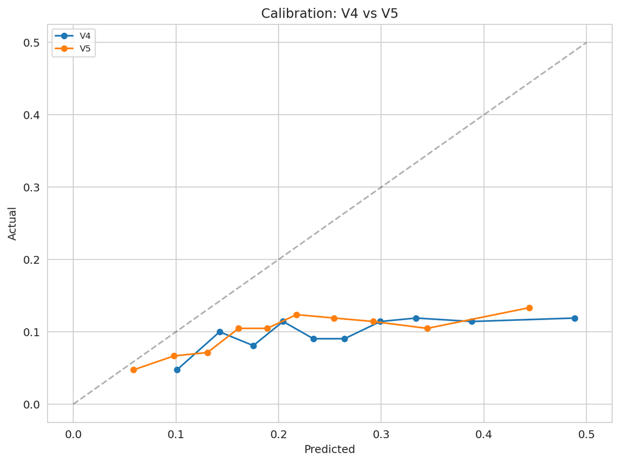

```
>>> 解读: joint regression 只说明增量预测内容, 不等于 '模型整体更优'.
```

```python
# Joint regression
m_j=smf.glm("defaulted ~ score_v4 + score_v5",data=us,family=sm.families.Binomial()).fit(cov_type="HC1")
stata_table(m_j, "Prediction: default ~ score_v4 + score_v5 (incremental content)")

# OOS metrics
print(f"\n{'─'*75}")
print(f"  Out-of-sample discrimination & calibration")
print(f"{'─'*75}")
for col,lab in [("score_v4","V4"),("score_v5","V5")]:
    auc=roc_auc_score(us["defaulted"],us[col])
    bs=brier_score_loss(us["defaulted"],us[col])
    ll=log_loss(us["defaulted"],np.clip(us[col].values,1e-7,1-1e-7))
    print(f"  {lab}: AUC={auc:.4f}, Brier={bs:.4f}, LogLoss={ll:.4f}")

# Calibration curves on same plot
fig,ax=plt.subplots(figsize=(8,6))
for col,c,lab in [("score_v4","C0","V4"),("score_v5","C1","V5")]:
    tmp=us.copy(); tmp["bin"]=pd.qcut(tmp[col].rank(method="first"),q=10,labels=False)
    cal=tmp.groupby("bin").agg(pred=(col,"mean"),actual=("defaulted","mean"))
    ax.plot(cal["pred"],cal["actual"],"o-",color=c,label=lab,ms=5)
ax.plot([0,.5],[0,.5],"k--",alpha=.3)
ax.set(xlabel="Predicted",ylabel="Actual",title="Calibration: V4 vs V5"); ax.legend()
plt.tight_layout(); plt.show()
print("\n>>> 解读: joint regression 只说明增量预测内容, 不等于 '模型整体更优'.")
```

## Part 11. 分解与综合结论

这里的分解只保留为 **heuristic bookkeeping**。  
其目的只是把 total gap 与当前证据层对齐，而不是声称已经正式识别了 selection 与 causal 的精确份额。

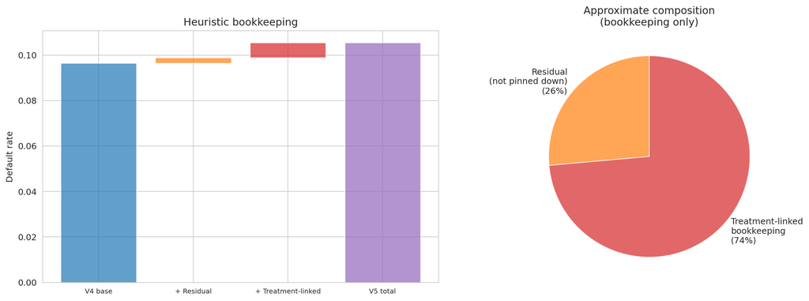

```
Total V5-V4 gap: +0.90%
Treatment-linked bookkeeping component: +0.6635% (~74% of total gap)
Residual not pinned down by current causal evidence: +0.2381% (~26% of total gap)
Interpretation: these percentages are only heuristic bookkeeping, not formal causal share attribution.
```

```python
# Heuristic bookkeeping only — not formal share attribution
dr_v4 = us[us["is_v5"] == 0]["defaulted"].mean()
dr_v5 = us[us["is_v5"] == 1]["defaulted"].mean()
total_eff = dr_v5 - dr_v4

inc_v4 = us[us["is_v5"] == 0]["is_inc"].mean()
inc_v5 = us[us["is_v5"] == 1]["is_inc"].mean()
inc_shift = inc_v5 - inc_v4

causal_gap = m2.loc[m2["is_inc"] == 1, "defaulted"].mean() - m2.loc[m2["is_inc"] == 0, "defaulted"].mean()
causal_comp = causal_gap * inc_shift
resid_comp = total_eff - causal_comp

fig, axes = plt.subplots(1, 2, figsize=(14, 5))

ax = axes[0]
ax.bar(0, dr_v4, color="C0", alpha=.7)
ax.bar(1, resid_comp, bottom=dr_v4, color="C1", alpha=.7)
ax.bar(2, causal_comp, bottom=dr_v4 + resid_comp, color="C3", alpha=.7)
ax.bar(3, dr_v5, color="C4", alpha=.7)
ax.set_xticks(range(4))
ax.set_xticklabels(["V4 base", "+ Residual", "+ Treatment-linked", "V5 total"], fontsize=8)
ax.set(ylabel="Default rate", title="Heuristic bookkeeping")

ax = axes[1]
if abs(total_eff) > 1e-5:
    sizes = [abs(resid_comp), abs(causal_comp)]
    ax.pie(
        sizes,
        labels=[
            f"Residual\n(not pinned down)\n({sizes[0] / sum(sizes) * 100:.0f}%)",
            f"Treatment-linked\nbookkeeping\n({sizes[1] / sum(sizes) * 100:.0f}%)",
        ],
        colors=["C1", "C3"],
        startangle=90,
        wedgeprops={"alpha": .7},
    )
    ax.set_title("Approximate composition\n(bookkeeping only)")
fig.tight_layout()
plt.show()

print(f"Total V5-V4 gap: {total_eff:+.2%}")
if abs(total_eff) > 1e-5:
    print(f"Treatment-linked bookkeeping component: {causal_comp:+.4%} (~{abs(causal_comp / total_eff) * 100:.0f}% of total gap)")
    print(f"Residual not pinned down by current causal evidence: {resid_comp:+.4%} (~{abs(resid_comp / total_eff) * 100:.0f}% of total gap)")
    print("Interpretation: these percentages are only heuristic bookkeeping, not formal causal share attribution.")
```

```python
print(f'''
{'═'*78}
  CONCLUSIONS (按证据强度分层)
{'═'*78}

  ┌─ 1. Shock 后 assignment pattern 发生了结构性变化 (强) ───────┐
  │  V5 inc rate 高于 V4, 且 score shift 是主要驱动之一          │
  │  给定 V4-score 的 policy mapping 也出现了可见变化            │
  │  → 说明 shock 的确重塑了谁更容易进入 inc                     │
  └──────────────────────────────────────────────────────────────┘

  ┌─ 2. Treatment path 与更高 hazard 相关 (主因果证据) ─────────┐
  │  Hazard model 中 tv_is_inc 为正, 控制 HD X 后方向稳定        │
  │  Cond / MSM 一致性检查总体同向                               │
  │  → 支持存在 treatment-induced causal component               │
  │  → 但 treatment 目前仍是 coarse binary is_inc                │
  └──────────────────────────────────────────────────────────────┘

  ┌─ 3. Matched comparison 方向一致 (辅助证据) ─────────────────┐
  │  Static matched estimand 下, inc 组 default 更高             │
  │  但该部分定位是 supporting evidence only                     │
  │  不能替代 survival 主线                                      │
  └──────────────────────────────────────────────────────────────┘

  ┌─ 4. Selection 诊断有弱的方向性证据 ─────────────────────────┐
  │  likely_excess 组 default rate 略高于 likely_natural         │
  │  但统计支持有限, 且构造仍依赖 heuristic push measure         │
  │  Feature diagnostics 只说明可能渠道, 不是正式识别            │
  │  → 当前更稳的表述是: selection evidence is weak but directional│
  └──────────────────────────────────────────────────────────────┘

  ┌─ 总叙事 ─────────────────────────────────────────────────────┐
  │  Risk increase 不能仅由 selection 完全解释,                  │
  │  同时也不能忽视 shock 对 assignment pattern 的重塑.          │
  │  当前最符合证据的解释是:                                     │
  │    selection + treatment-induced causal component 并存,      │
  │    其中 survival 证据更直接支持后者,                         │
  │    selection 诊断目前只提供较弱的方向性线索.                 │
  └──────────────────────────────────────────────────────────────┘

  当前证据边界:
  - Maintained assumption: Y(a) ⟂ A_t | X_t
  - Treatment 为 coarse binary is_inc (未纳入 dose / regime heterogeneity)
  - Matching balance 与样本量仍有限
  - Selection 诊断依赖 cell-level heuristic push measure
  - Bookkeeping 分解不是正式的 share attribution
{'═'*78}
''')
```

```
══════════════════════════════════════════════════════════════════════════════
  CONCLUSIONS (按证据强度分层)
══════════════════════════════════════════════════════════════════════════════

  ┌─ 1. Shock 后 assignment pattern 发生了结构性变化 (强) ───────┐
  │  V5 inc rate 高于 V4, 且 score shift 是主要驱动之一          │
  │  给定 V4-score 的 policy mapping 也出现了可见变化            │
  │  → 说明 shock 的确重塑了谁更容易进入 inc                     │
  └──────────────────────────────────────────────────────────────┘

  ┌─ 2. Treatment path 与更高 hazard 相关 (主因果证据) ─────────┐
  │  Hazard model 中 tv_is_inc 为正, 控制 HD X 后方向稳定        │
  │  Cond / MSM 一致性检查总体同向                               │
  │  → 支持存在 treatment-induced causal component               │
  │  → 但 treatment 目前仍是 coarse binary is_inc                │
  └──────────────────────────────────────────────────────────────┘

  ┌─ 3. Matched comparison 方向一致 (辅助证据) ─────────────────┐
  │  Static matched estimand 下, inc 组 default 更高             │
  │  但该部分定位是 supporting evidence only                     │
  │  不能替代 survival 主线                                      │
  └──────────────────────────────────────────────────────────────┘

  ┌─ 4. Selection 诊断有弱的方向性证据 ─────────────────────────┐
  │  likely_excess 组 default rate 略高于 likely_natural         │
  │  但统计支持有限, 且构造仍依赖 heuristic push measure         │
  │  Feature diagnostics 只说明可能渠道, 不是正式识别            │
  │  → 当前更稳的表述是: selection evidence is weak but directional│
  └──────────────────────────────────────────────────────────────┘

  ┌─ 总叙事 ─────────────────────────────────────────────────────┐
  │  Risk increase 不能仅由 selection 完全解释,                  │
  │  同时也不能忽视 shock 对 assignment pattern 的重塑.          │
  │  当前最符合证据的解释是:                                     │
  │    selection + treatment-induced causal component 并存,      │
  │    其中 survival 证据更直接支持后者,                         │
  │    selection 诊断目前只提供较弱的方向性线索.                 │
  └──────────────────────────────────────────────────────────────┘

  当前证据边界:
  - Maintained assumption: Y(a) ⟂ A_t | X_t
  - Treatment 为 coarse binary is_inc (未纳入 dose / regime heterogeneity)
  - Matching balance 与样本量仍有限
  - Selection 诊断依赖 cell-level heuristic push measure
  - Bookkeeping 分解不是正式的 share attribution
══════════════════════════════════════════════════════════════════════════════
```